# Course Project 2

George Farmer

1/22/2021

#Reproducible Research - Course Project 2

##A critical analysis of weather data and patterns through the NOAA Storm Database and how storms effect Economics and Health.

###Synopsis

Storms and other severe weather events can cause both public health and economic problems for communities and municipalities. Many severe events can result in fatalities, injuries, and property damage, and preventing such outcomes to the extent possible is a key concern.

This database, (The NOAA Storm Tracker Database) tracks characteristics of major storms and weather events in the United States, including when and where they occur, as well as estimates of any fatalities, injuries, and property damage. My analysis shows that in terms of human collateral damage and injury, Tornadoes are the biggest overall threat while in terms of shear destructive power Flooding and Flash Flooding cause multibillions of dollars in damages as well as Hurricanes.

```r
#Setting work enviroment
knitr::opts_chunk$set(echo = TRUE)
knitr::opts_chunk$set(error = TRUE)
knitr::opts_chunk$set(warning = FALSE)
knitr::opts_chunk$set(dev="png")
#Loading relevant Libraries
library(ggplot2)
library(plyr)
library(dplyr)
#Set working directory
here <- getwd()
setwd(here)
```

###Data Download

Downloading data set from National Weather Service via: https://d396qusza40orc.cloudfront.net/repdata%2Fdata%2FStormData.csv.bz2

Additional information is avaliable from: https://d396qusza40orc.cloudfront.net/repdata%2Fpeer2_doc%2Fpd01016005curr.pdf

And an FAQ at: https://d396qusza40orc.cloudfront.net/repdata%2Fpeer2_doc%2FNCDC%20Storm%20Events-FAQ%20Page.pdf

```r
#Download Data
fileUrl<-"https://d396qusza40orc.cloudfront.net/repdata%2Fdata%2FStormData.csv.bz2"
download.file(fileUrl, destfile="StormData.csv.bz2", method="curl")
path_rf <- file.path("./repdata%2Fdata%2FStormData")

#Assigning variable to data
stormData <- read.csv("StormData.csv.bz2")
str(stormData)
```

```
## 'data.frame':    902297 obs. of  37 variables:
##  $ STATE__   : num  1 1 1 1 1 1 1 1 1 1 ...
##  $ BGN_DATE  : chr  "4/18/1950 0:00:00" "4/18/1950 0:00:00" "2/20/1951 0:00:00" "6/8/1951 0:00:00" ...
##  $ BGN_TIME  : chr  "0130" "0145" "1600" "0900" ...
##  $ TIME_ZONE : chr  "CST" "CST" "CST" "CST" ...
##  $ COUNTY    : num  97 3 57 89 43 77 9 123 125 57 ...
##  $ COUNTYNAME: chr  "MOBILE" "BALDWIN" "FAYETTE" "MADISON" ...
##  $ STATE     : chr  "AL" "AL" "AL" "AL" ...
##  $ EVTYPE    : chr  "TORNADO" "TORNADO" "TORNADO" "TORNADO" ...
##  $ BGN_RANGE : num  0 0 0 0 0 0 0 0 0 0 ...
##  $ BGN_AZI   : chr  "" "" "" "" ...
##  $ BGN_LOCATI: chr  "" "" "" "" ...
##  $ END_DATE  : chr  "" "" "" "" ...
##  $ END_TIME  : chr  "" "" "" "" ...
##  $ COUNTY_END: num  0 0 0 0 0 0 0 0 0 0 ...
```

[output cut: 23 more lines]

The events in the database start in the year 1950 and end in November 2011. In the earlier years of the database there are generally fewer events recorded, most likely due to a lack of good records. More recent years should be considered more complete.

```r
dim(stormData)
```

```
## [1] 902297     37
```

This Database contains a extraordinary amount of data with 37 variables and 902297 records. A lot of these variables give coordinates, cities where they occur. but what we want to look at in particular are the Length, Width, F category, magnitude, Fatalities, Property and crop damage and when they occurred.

###Extracting Variables

```r
#Extracting Variables
variables <- c("EVTYPE", "LENGTH", "WIDTH", "F", "MAG", "FATALITIES", "INJURIES", "PROPDMGEXP", "PROPDMG", "CROPDMG", "CROPDMGEXP")

#Putting variables in a new data set
stormDamage <- stormData[, variables]
```

Now we can begin working with the specific data we need and break them down into categories, and look for the usual suspect, so to speak. Here’s a list of the top 10 highest storms on the chart.

```r
sort(table(stormDamage$EVTYPE), decreasing = TRUE)[1:10]
```

```
##
##               HAIL          TSTM WIND  THUNDERSTORM WIND            TORNADO
##             288661             219940              82563              60652
##        FLASH FLOOD              FLOOD THUNDERSTORM WINDS          HIGH WIND
##              54277              25326              20843              20212
##          LIGHTNING         HEAVY SNOW
##              15754              15708
```

The Property and Crop damage need some cleaning up so that it’s a useable data set,

```r
table(stormDamage$PROPDMGEXP)
```

```
##
##             -      ?      +      0      1      2      3      4      5      6
## 465934      1      8      5    216     25     13      4      4     28      4
##      7      8      B      h      H      K      m      M
##      5      1     40      1      6 424665      7  11330
```

```r
table(stormDamage$CROPDMGEXP)
```

```
##
##             ?      0      2      B      k      K      m      M
## 618413      7     19      1      9     21 281832      1   1994
```

Both exponents are converted to uppercase to adapt all the exponents with the same meaning (eg. h and H). The next steps convert the exponents into corresponding factors: “”, “?”, “+”, “-”: 1 “0”: 1 “1”: 10 “2”: 100 “3”: 1.000 “4”: 10.000 “5”: 100.000 “6”: 1.000.000 “7”: 10.000.000 “8”: 100.000.000 “9”: 1.000.000.000 “H”: 100 “K”: 1.000 “M”: 1.000.000 *“B”: 1.000.000.000

```r
#Changing the case of the records for legibility
stormDamage$PROPDMGEXP <- toupper(stormDamage$PROPDMGEXP)
stormDamage$CROPDMGEXP <- toupper(stormDamage$CROPDMGEXP)

#Assigning damage amounts the variables
stormDamage$CROPDMGFACTOR[(stormDamage$CROPDMGEXP == "")] <- 10^0
stormDamage$CROPDMGFACTOR[(stormDamage$CROPDMGEXP == "?")] <- 10^0
stormDamage$CROPDMGFACTOR[(stormDamage$CROPDMGEXP == "0")] <- 10^0
stormDamage$CROPDMGFACTOR[(stormDamage$CROPDMGEXP == "2")] <- 10^2
stormDamage$CROPDMGFACTOR[(stormDamage$CROPDMGEXP == "K")] <- 10^3
stormDamage$CROPDMGFACTOR[(stormDamage$CROPDMGEXP == "M")] <- 10^6
stormDamage$CROPDMGFACTOR[(stormDamage$CROPDMGEXP == "B")] <- 10^9
stormDamage$PROPDMGFACTOR[(stormDamage$PROPDMGEXP == "")] <- 10^0
stormDamage$PROPDMGFACTOR[(stormDamage$PROPDMGEXP == "-")] <- 10^0
stormDamage$PROPDMGFACTOR[(stormDamage$PROPDMGEXP == "?")] <- 10^0
stormDamage$PROPDMGFACTOR[(stormDamage$PROPDMGEXP == "+")] <- 10^0
stormDamage$PROPDMGFACTOR[(stormDamage$PROPDMGEXP == "0")] <- 10^0
stormDamage$PROPDMGFACTOR[(stormDamage$PROPDMGEXP == "1")] <- 10^1
stormDamage$PROPDMGFACTOR[(stormDamage$PROPDMGEXP == "2")] <- 10^2
stormDamage$PROPDMGFACTOR[(stormDamage$PROPDMGEXP == "3")] <- 10^3
stormDamage$PROPDMGFACTOR[(stormDamage$PROPDMGEXP == "4")] <- 10^4
stormDamage$PROPDMGFACTOR[(stormDamage$PROPDMGEXP == "5")] <- 10^5
stormDamage$PROPDMGFACTOR[(stormDamage$PROPDMGEXP == "6")] <- 10^6
stormDamage$PROPDMGFACTOR[(stormDamage$PROPDMGEXP == "7")] <- 10^7
stormDamage$PROPDMGFACTOR[(stormDamage$PROPDMGEXP == "8")] <- 10^8
stormDamage$PROPDMGFACTOR[(stormDamage$PROPDMGEXP == "H")] <- 10^2
stormDamage$PROPDMGFACTOR[(stormDamage$PROPDMGEXP == "K")] <- 10^3
stormDamage$PROPDMGFACTOR[(stormDamage$PROPDMGEXP == "M")] <- 10^6
stormDamage$PROPDMGFACTOR[(stormDamage$PROPDMGEXP == "B")] <- 10^9

#Displaying Results
sort(table(stormDamage$PROPDMGFACTOR), decreasing = TRUE)[1:10]
```

```
##
##      1   1000  1e+06  1e+09  1e+05     10    100  1e+07  10000  1e+08
## 466164 424669  11341     40     28     25     20      5      4      1
```

```r
sort(table(stormDamage$CROPDMGFACTOR), decreasing = TRUE)[1:10]
```

```
##
##      1   1000  1e+06  1e+09    100   <NA>   <NA>   <NA>   <NA>   <NA>
## 618439 281853   1995      9      1
```

In this case it might be important to note the lack of data in the Crop Damage as compared to the Property damage, so will leave that be.

###Data Analysis

It would be good to look at different parts of this and to analyze different aspects.

```r
injuries <- stormDamage %>% group_by(INJURIES) %>%
                filter(INJURIES >= 1) %>%
                arrange(desc(INJURIES))
injuries
```

```
## # A tibble: 17,604 x 13
## # Groups:   INJURIES [199]
##    EVTYPE LENGTH WIDTH     F   MAG FATALITIES INJURIES PROPDMGEXP PROPDMG
##    <chr>   <dbl> <dbl> <int> <dbl>      <dbl>    <dbl> <chr>        <dbl>
##  1 TORNA~   12.9  1760     4     0         42     1700 M           250
##  2 ICE S~    0       0    NA     0          1     1568 M            50
##  3 TORNA~   34.9   900     4     0         90     1228 M           250
##  4 TORNA~   20.4   533     5     0         36     1150 M           250
##  5 TORNA~    9    1600     5     0        158     1150 B             2.8
##  6 FLOOD     0       0    NA     0          2      800 M            50
##  7 TORNA~   42    1760     4     0         44      800 B             1.5
##  8 TORNA~    9.6   833     5     0        116      785 M            25
##  9 HURRI~    0       0    NA     0          7      780 B             5.42
## 10 FLOOD     0       0    NA     0          0      750 M           268
## # ... with 17,594 more rows, and 4 more variables: CROPDMG <dbl>,
## #   CROPDMGEXP <chr>, CROPDMGFACTOR <dbl>, PROPDMGFACTOR <dbl>
```

Here we have Injuries sorted by highest injury count to the lowest, leaving out any incidents with 0 injuries.

```r
fatalities <- stormDamage %>% group_by(FATALITIES) %>%
                filter(FATALITIES >= 1) %>%
                arrange(desc(FATALITIES))
fatalities
```

```
## # A tibble: 6,974 x 13
## # Groups:   FATALITIES [51]
##    EVTYPE LENGTH WIDTH     F   MAG FATALITIES INJURIES PROPDMGEXP PROPDMG
##    <chr>   <dbl> <dbl> <int> <dbl>      <dbl>    <dbl> <chr>        <dbl>
##  1 HEAT      0       0    NA     0        583        0 ""             0
##  2 TORNA~    9    1600     5     0        158     1150 "B"            2.8
##  3 TORNA~    9.6   833     5     0        116      785 "M"           25
##  4 TORNA~   20.9   583     5     0        114      597 "M"           25
##  5 EXCES~    0       0    NA     0         99        0 ""             0
##  6 TORNA~   34.9   900     4     0         90     1228 "M"          250
##  7 TORNA~    2.3  1320     5     0         75      270 "K"          250
##  8 EXCES~    0       0    NA     0         74      135 ""             0
##  9 EXCES~    0       0    NA     0         67        0 ""             0
## 10 TORNA~   27.8    33     5     0         57      504 "M"           25
## # ... with 6,964 more rows, and 4 more variables: CROPDMG <dbl>,
## #   CROPDMGEXP <chr>, CROPDMGFACTOR <dbl>, PROPDMGFACTOR <dbl>
```

And here we have Fatalities sorted by highest fatality count to the lowest leaving out any incidents with 0 fatalities. I left in the data on the size and length of the storm as well as its F-Scale to determine exactly what that particular tornado was.

Next creating tables for Crop and Property damage

```r
#Cleaning up Crop Damage data
stormDamage <- mutate(stormDamage, cropDamage = CROPDMG * CROPDMGFACTOR)

#Cleaning up Property Damage and adding in Crop Damage as that is property damage as well.
stormDamage <- mutate(stormDamage, propDamage = cropDamage + PROPDMG * PROPDMGFACTOR)

#Filtering Property and Crop Damage

cropDamage1 <- stormDamage %>% group_by(cropDamage) %>%
                filter(cropDamage >= 1) %>%
                arrange(desc(cropDamage))
cropDamage1
```

```
## # A tibble: 22,099 x 15
## # Groups:   cropDamage [528]
##    EVTYPE LENGTH WIDTH     F   MAG FATALITIES INJURIES PROPDMGEXP PROPDMG
##    <chr>   <dbl> <dbl> <int> <dbl>      <dbl>    <dbl> <chr>        <dbl>
##  1 RIVER~      0     0    NA     0          0        0 "B"           5
##  2 ICE S~      0     0    NA     0          0        0 "K"         500
##  3 HURRI~      0     0    NA     0         15      104 "B"           5.88
##  4 DROUG~      0     0    NA     0          0        0 ""            0
##  5 EXTRE~      0     0    NA     0          0        0 ""            0
##  6 DROUG~      0     0    NA     0          0        0 ""            0
##  7 DROUG~      0     0    NA     0          0        0 ""            0
##  8 DROUG~      0     0    NA     0          0        0 ""            0
##  9 DROUG~      0     0    NA     0          0        0 ""            0
## 10 HURRI~      0     0    NA     0          0        0 "B"           3
## # ... with 22,089 more rows, and 6 more variables: CROPDMG <dbl>,
## #   CROPDMGEXP <chr>, CROPDMGFACTOR <dbl>, PROPDMGFACTOR <dbl>,
## #   cropDamage <dbl>, propDamage <dbl>
```

And next we filter Property Damage as that is important as well, as not all damage that happens to property is crop related.

```r
propDamage1 <- stormDamage %>% group_by(propDamage) %>%
                filter(propDamage >= 1) %>%
                arrange(desc(propDamage))
propDamage1
```

```
## # A tibble: 245,026 x 15
## # Groups:   propDamage [2,158]
##    EVTYPE LENGTH WIDTH     F   MAG FATALITIES INJURIES PROPDMGEXP PROPDMG
##    <chr>   <dbl> <dbl> <int> <dbl>      <dbl>    <dbl> <chr>        <dbl>
##  1 FLOOD       0     0    NA     0          0        0 B           115
##  2 STORM~      0     0    NA     0          0        0 B            31.3
##  3 HURRI~      0     0    NA     0          0        0 B            16.9
##  4 STORM~      0     0    NA     0          0        0 B            11.3
##  5 RIVER~      0     0    NA     0          0        0 B             5
##  6 HURRI~      0     0    NA     0          5        0 B            10
##  7 HURRI~      0     0    NA     0         15      104 B             5.88
##  8 HURRI~      0     0    NA     0          0        0 B             7.35
##  9 HURRI~      0     0    NA     0          7      780 B             5.42
## 10 TROPI~      0     0    NA     0         22        0 B             5.15
## # ... with 245,016 more rows, and 6 more variables: CROPDMG <dbl>,
## #   CROPDMGEXP <chr>, CROPDMGFACTOR <dbl>, PROPDMGFACTOR <dbl>,
## #   cropDamage <dbl>, propDamage <dbl>
```

But first, we need to clean up the EVTYPE data.

```r
stormDamage$EVTYPE <- toupper(stormDamage$EVTYPE)
dim(data.frame(table(stormDamage$EVTYPE)))
```

```
## [1] 898   2
```

There are over 898 types of Environmental Type records, most of them repeats or named something incredibly specific. As much as I have tried to get as much of this information as possible. This will not work.

But first condensing the Health and Economic impacts of the storm into two categories.

```r
stormDamage <- mutate(stormDamage, healthImp = FATALITIES + INJURIES)
stormDamage <- mutate(stormDamage, ecoCost = PROPDMG * PROPDMGFACTOR + CROPDMG * CROPDMGFACTOR)
```

Now to clean up the EVTYPE data.

```r
healthImpact <- with(stormDamage, aggregate(healthImp ~ EVTYPE, FUN = sum))
subset(healthImpact, healthImp > quantile(healthImp, prob = 0.95))
```

```
##                      EVTYPE healthImp
## 19                AVALANCHE       394
## 28                 BLIZZARD       906
## 69          COLD/WIND CHILL       107
## 78                DENSE FOG       360
## 105              DUST STORM       462
## 116          EXCESSIVE HEAT      8428
## 125            EXTREME COLD       393
## 126 EXTREME COLD/WIND CHILL       149
## 127            EXTREME HEAT       251
## 138             FLASH FLOOD      2755
## 154                   FLOOD      7259
## 171                     FOG       796
## 195                   GLAZE       223
## 212                    HAIL      1376
```

[output cut: 30 more lines]

```r
economicCost <- with(stormDamage, aggregate(ecoCost ~ EVTYPE, FUN = sum))
subset(economicCost, ecoCost > quantile(ecoCost, prob = 0.95))
```

```
##                         EVTYPE      ecoCost
## 28                    BLIZZARD    771273950
## 49               COASTAL FLOOD    259570560
## 76             DAMAGING FREEZE    304230000
## 84                     DROUGHT  15018672000
## 116             EXCESSIVE HEAT    500155700
## 125               EXTREME COLD   1380710400
## 138                FLASH FLOOD  18243991079
## 146          FLASH FLOOD/FLOOD    273005006
## 149             FLASH FLOODING    322879654
## 154                      FLOOD 150319678257
## 160          FLOOD/FLASH FLOOD    269095007
## 174                     FREEZE    456930000
## 187               FROST/FREEZE   1104666000
## 212                       HAIL  18761221986
```

[output cut: 31 more lines]

Now the list has gone from 898 to 44 and 45 records respectively, narrowing down the numbers considerably

###Results

```r
healthImpact2 <- stormDamage %>%
                group_by(EVTYPE) %>%
                summarise(healthImp = sum(healthImp)) %>%
                arrange(desc(healthImp))
```

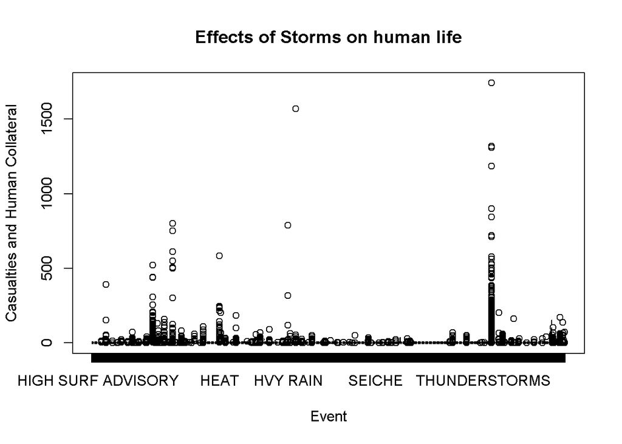

```r
boxplot(healthImp~EVTYPE,data=stormDamage, main="Effects of Storms on human life",
   xlab="Event", ylab="Casualties and Human Collateral")
```

Apologies for the crude graph, but with the amount of data available this was the best choice and I didn’t want to break the graph further.

Tornadoes seem to be one of the highest sources of human collateral.

The cleaned data frame stormDamage is been aggregated per EVTYPE and provided in a descending order in the new data frame economicCost.

```r
economicCost <- stormDamage %>%
                group_by(EVTYPE) %>%
                summarise(ecoCost = sum(ecoCost)) %>%
                arrange(desc(ecoCost))
```

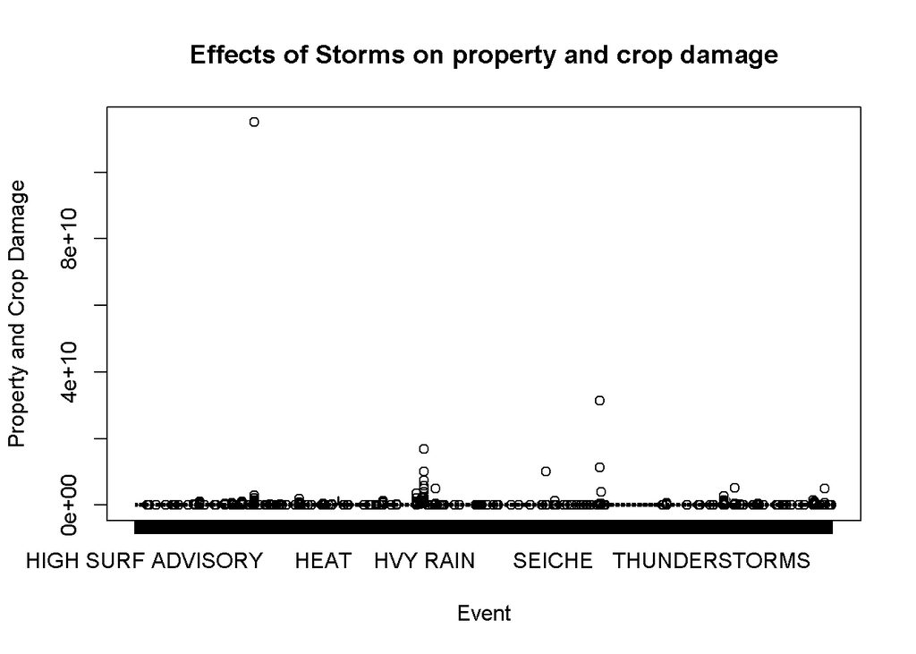

```r
boxplot(ecoCost~EVTYPE,data=stormDamage, main="Effects of Storms on property and crop damage",
   xlab="Event", ylab="Property and Crop Damage")
```

Floods, flash floods, and Hurricanes have caused exorbitant amounts of damage combined, somewhere in the hundreds of billions of dollars in property damage.

In conclusion Tornadoes and Flooding have created the most damage to ourselves and the environment.